# Elaborar Sintáxis en R

## ¿Qué aprenderemos?

En esta sesión aprenderemos como escribir el código de R de la forma más adecuada. Ya hemos visto los tipos de datos y operadores básicos para trabajar, ahora entederemos como emplear esta información para generar bases, manejardatos y realizar análisis.

A continuación revisaremos conceptos fundamentales, estilo de escritura y operadores lógicos.

## Vector

Un vector es la estructura de datos más sencilla en R. Un vector es una colección de uno o más datos del mismo tipo.

La palabra vector será usada muchas veces por el programa para referirse a los objetos con los que trabajamos.

Todo vector tiene tres propiedades:

- Tipo: dependerá del tipo de datos que contiene
- Largo: el número de elementos que contiene el vector
- Atributos: los metadatos del vector. Esta característica sobresale más cuando trabajamos con datos extraídos de SPSS o bases de datos en otros formatos.

## Espacio de Trabajo

Antes de empezar a escribir una nueva sintáxis es necesario asegurar dos cosas:

- Que el environment esté limpio
- Saber en qué directorio estamos almacenando nuestros archivos.

## Limpiar el ambiente y directorio de trabajo

```r
## Para limpiar el escritorio
"rm(ls=list())"
```

```
## [1] "rm(ls=list())"
```

```r
# la funcion rm() remueve objetos
# la sintáxis ls=list() hace referencia a todos los objetos en tu entorno de trabajo

"getwd()" # para saber en que directorio estás trabajando
```

```
## [1] "getwd()"
```

```r
"setwd()" # para establecer el directorio donde trabajamos
```

```
## [1] "setwd()"
```

En R para indicar el directorio de trabajo es importante escribir con “/” la dirección de las carpetas por ejemplo “C:/Mis documentos/Proyecto”

En el caso de realizar un proyecto compartido hay otras formas de trabajo que hablaremos luego,

Si van a usar estas funciones USENLAS EN LA CONSOLA, no en el editor.

## Botones en RStudio para limpiar el ambiente

[figure not shown]

## Estilo de escritura

Existen convenciones establecidas para asegurar con guion de R pueda ser leído e interpretado por otros. En esta sección revisaremos:

- Organización de código
- Nombre de objetos
- Espaciado
- Largo de las líneas

## Organización de códigos

Cuando se trabaja un guión se suele usar paquetes. En otra sesión hablaremos sobre lo que es un paquete, pero por el momento lo importante es saber que si usamos paquetes en nuestro trabajo estos tienen que estar cargados en la parte de arriba.

También, es importante mantener un orden en el código. Es una buena práctica separar cada sección mediante “## Nombre—-”

```r
# Dividir partes de los códigos claramante

## Ejercicio1 --------

var_numero <- 45

## Ejercicio2 --------

var_caracter <- "Hola Mundo"
```

## Nombre de Objetos

Los nombres de las variables que asignemos tienen que ser cortos, describir bien a la variable, en minúsculas y sin espacios.

Se puede utilizar “_” para separar palabras.

```r
# Ejemplos adecuados

productos_vendidos <- 5
precio_promedio <- 45
costo_promedio <- -34
facturacion_total <- 5 * 45

## Ejemplos no adecuados

Prod..vendidos <- 5
Precio.Promedio <- 45
```

## Espaciado y Largo de Códigos

La mayoría de operadores deben de ir espacios: “+”, “<-”, “*“.

Además, después de cada coma debe de ir un espacio para que pueda ser más legible el código “,”.

El único operador que no debe de ir con espacios es el de potencia “2^2”. Si se pudiera un espacio, cuando se evalue el código R no entenderá la operación que se está solicitando.

Sobre la extensión de código, el máximo de cada línea debe de ser 80 caracteres. Si se pasa de este largo, hay que usar el botón Enter y seguir escribiendo a partir de ahí.

## Operadores Lógicos

Mucho del trabajo en R, en especial para limpiar datos, consiste en usar adecuadamente condicionales y operaciones lógicas. A continuación daremos un listado de las operaciones lógicas más comunes.

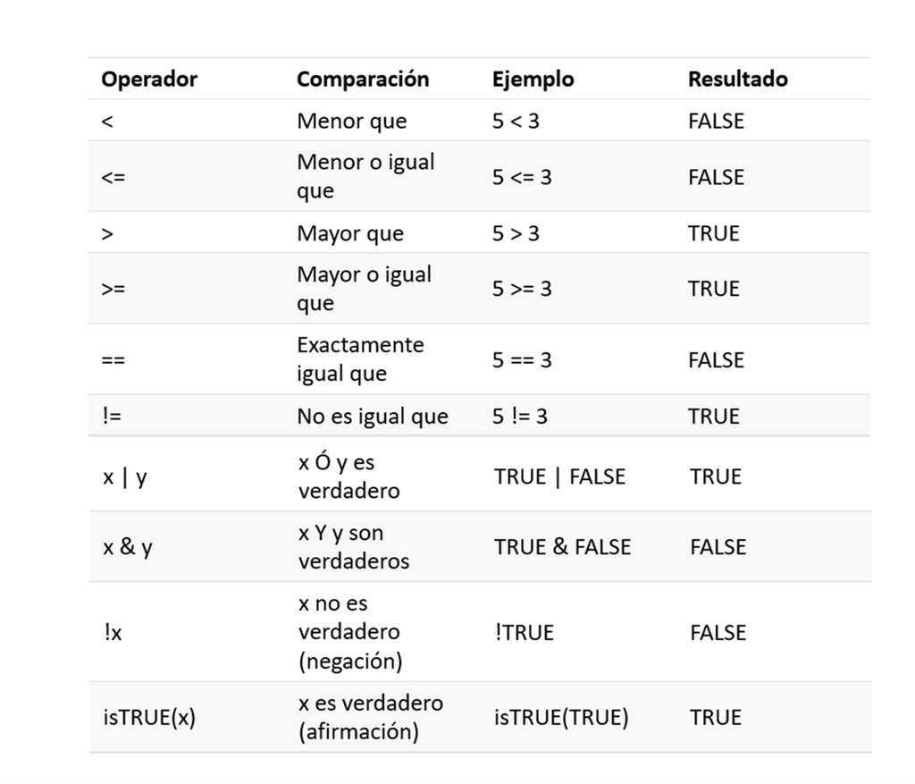